# Homework 3

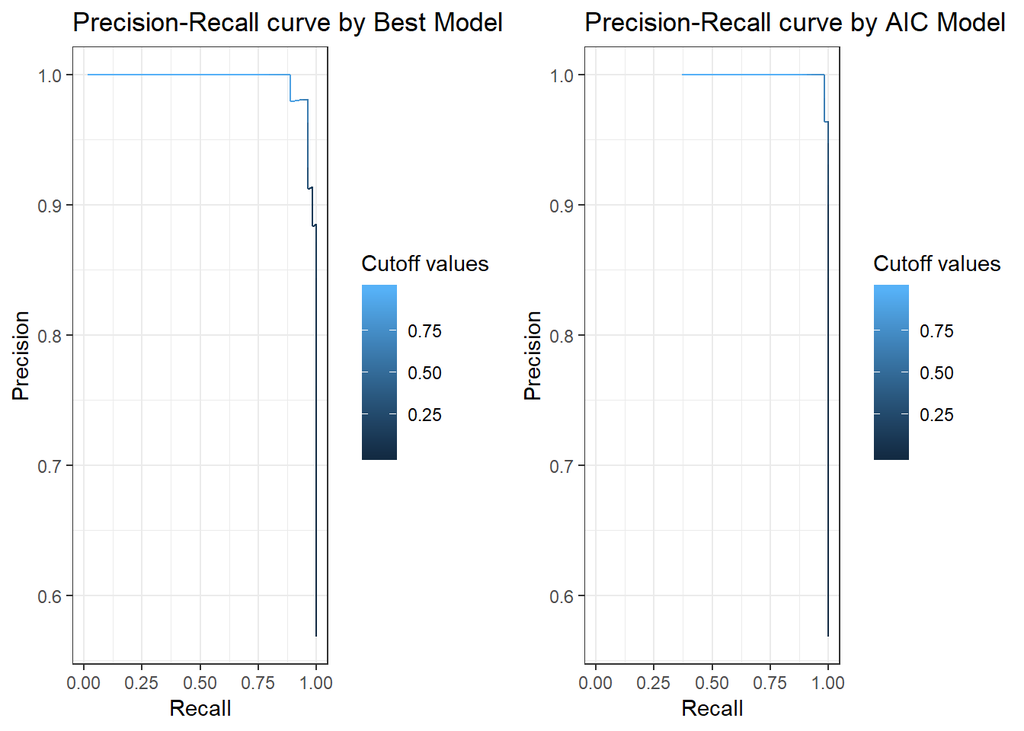

```r
Recall<-unlist(perf2@x.values)
Precision<-unlist(perf2@y.values)
Alpha<-unlist(perf2@alpha.values)
bios2<-data.frame(Recall,Precision,Alpha)
PRC_AIC<-ggplot(bios2,aes(x=Recall,y=Precision,color=Alpha))+geom_line()+ theme_bw()+ labs(x='Recall',y='Precision',title='Precision-Recall curve by AIC Model',color='Cutoff values')


grid.arrange(PRC1,PRC_AIC,nrow=1)
```

```r
library(pROC)
```

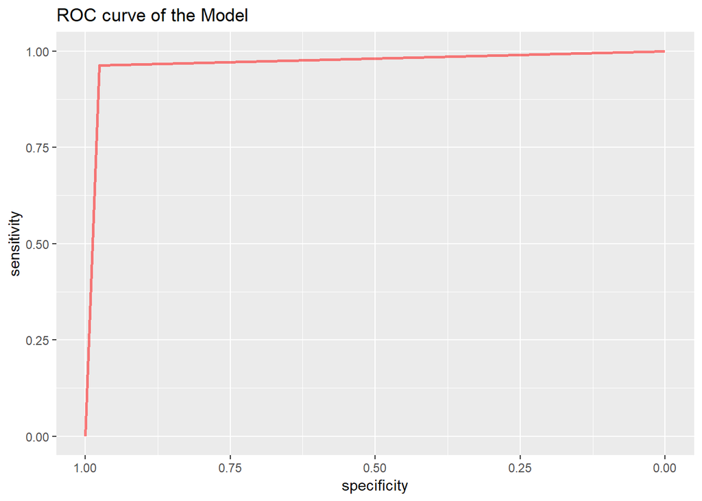

```r
Roc<-roc(Test$class,pr_class)
plt1<-ggroc(Roc,alpha = 0.5, colour = "red", linetype = 1, size = 1)+ggtitle("ROC curve of the Model")
plt1
```

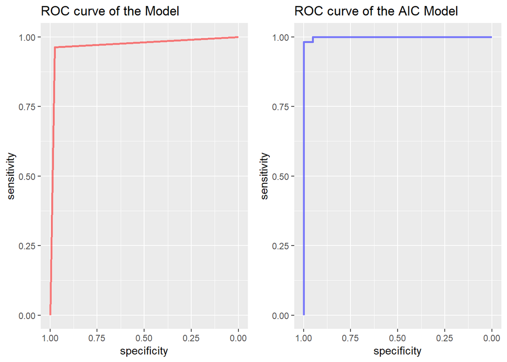

```r
Roc2<-roc(Test$class,pr_AIC)
plt2<-ggroc(Roc2,alpha = 0.5, colour = "blue", linetype = 1, size = 1)+ggtitle("ROC curve of the AIC Model ")

grid.arrange(plt1, plt2,nrow=1)
```

ROC curve represents relationship between RECALL(True Positive Rate) and False Positive Rate, while PRC curve represents relationship between RECALL(True positive Rate) and PRECISION.We can use PRC when we have a class imbalance,or when detecting a rare positive case is much more important than detecting negative case. In our case our data is more or less balances(43% and 57%),so we can use ROC curve.By plots(PRC and ROC curves) we see that AIC model predicted better than our model,because curve of AIC model is closer to 1 in both plots.

**Bonus. 2 pt**

While evaluating the goodness of fit of the first model I used the Hosmer-Lemeshow test. The Chi-square value of 9.156 is displayed on my output. Try to calculate this number without any extra libraries. Do not use the same functions which are written in Hosmer-Lemeshow test in R. **Hint:** Firstly you should understand the meaning of this test. I leave the first part of my code to obtain the same result and to help you solve the problem.

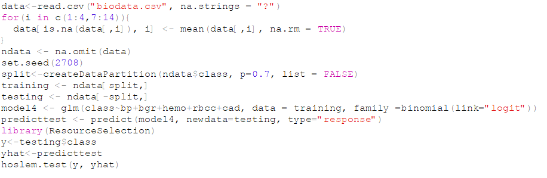

**Please, make brief and meaningful conclusions.**